# Summary statistics of simulated variants and extractred ancestral sequences

2023-07-31

# Variant simulator; report

### Node used for reconstructing ancestral genome sequence

If a (newick) phylogenetic tree file has been provided, the visualisation of the MSA used in the calculations is shown below. The two chosen groups (i.e. ‘ingroup’ / species of interest, and outgroup) are highlighted in the tree. The outgroup, used in the computation or not, is the outgroup, which together with the reference species of interest coalesce at the node of interest, from which the ancestral sequence have been extracted. Most recent common ancestor (MRCA) is highlighted in purple and labeled. The rest of the clades in the alignment are shown in lighter grey. Regardless whether a reconstructed ancestral sequence at a node, or an outgroup, has been chosen as the ancestor, the MRCA will be highlighted.

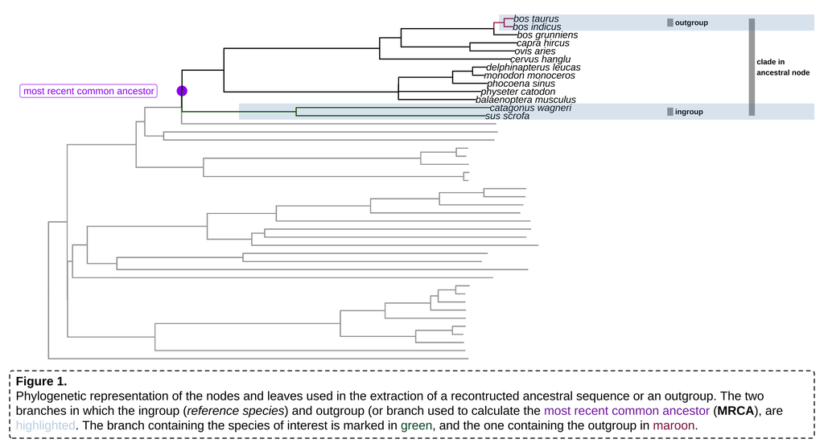

### Distribution of simulated variants across the reference genome

If an ideogram (often possible to download on the UCSC website, [here](https://genome.ucsc.edu/cgi-bin/hgTables)) has been provided, the distribution of simulated variants is shown across the genome of the species of interest. The grey distribution corresponds to the total amount of simulated variants, whereas the red distribution corresponds to the subset that is overlapping with a corresponding non-gap ancestral sequence. If there is no forced sub-sampling due to lack of ancestral sequence, the distribution will be fully red.

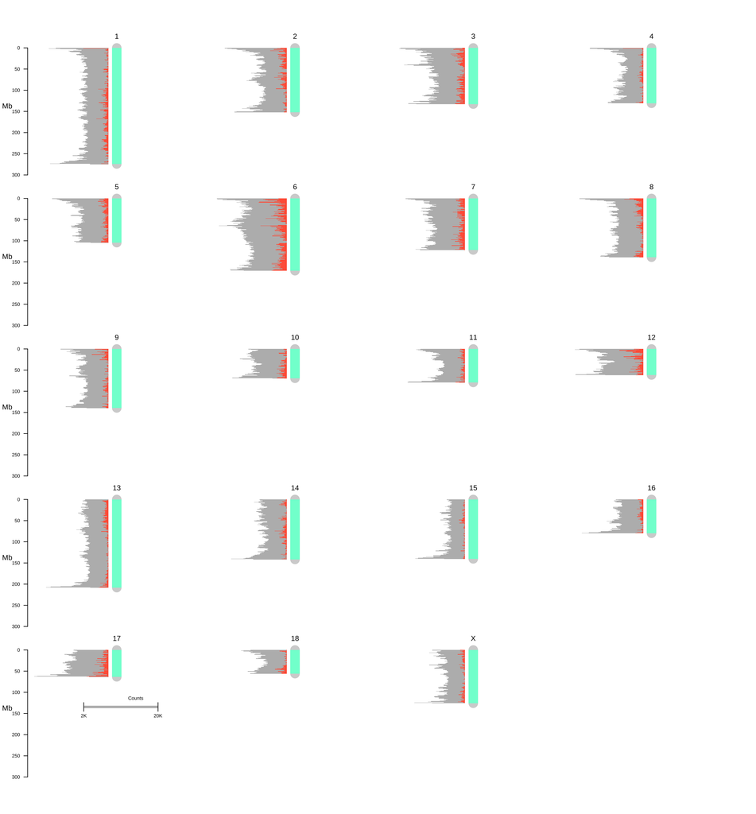

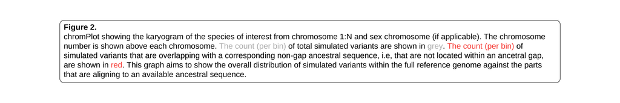

### How much of the reference genome that has an available, aligned reconstructed ancestral sequence

**Table 1** Fraction of refence genome that has an available aligned reconstructed ancestral sequence. The leftmost column represents the total size of the source chromosome (in base pairs), from the species of interest. The middle column represents the size (in base pairs) of the recontructed ancestral genome (or size of aligned outgroup without gaps). The rightmost column represents the fraction of the reference genome that is covered by an ancestral sequence, i.e. the fraction of the reference with a corresponding non-gap ancestral alignment.

|  | Size of ref. genome | Size of reconstructed genome | Fraction covered of ref. genome |
| --- | --- | --- | --- |
| 1 | 274 330 532 | 26 986 869 | 0.10 |
| 2 | 151 935 994 | 15 739 413 | 0.10 |
| 3 | 132 848 913 | 16 042 762 | 0.12 |
| 4 | 130 910 915 | 8 244 024 | 0.06 |
| 5 | 104 526 007 | 12 389 715 | 0.12 |
| 6 | 170 843 587 | 27 541 924 | 0.16 |
| 7 | 121 844 099 | 16 685 999 | 0.14 |
| 8 | 138 966 237 | 14 781 220 | 0.11 |
| 9 | 139 512 083 | 12 093 804 | 0.09 |
| 10 | 69 359 453 | 7 166 746 | 0.10 |
| 11 | 79 169 978 | 7 401 759 | 0.09 |
| 12 | 61 602 749 | 8 675 020 | 0.14 |
| 13 | 208 334 590 | 18 283 771 | 0.09 |
| 14 | 141 755 446 | 12 494 466 | 0.09 |
| 15 | 140 412 725 | 7 607 655 | 0.05 |
| 16 | 79 944 280 | 7 242 297 | 0.09 |
| 17 | 63 494 081 | 8 975 571 | 0.14 |
| 18 | 55 982 971 | 4 431 285 | 0.08 |
| X | 125 939 595 | 10 403 489 | 0.08 |

### Number of simulated variants

##### and how many are overlapping with an available ancestral sequence

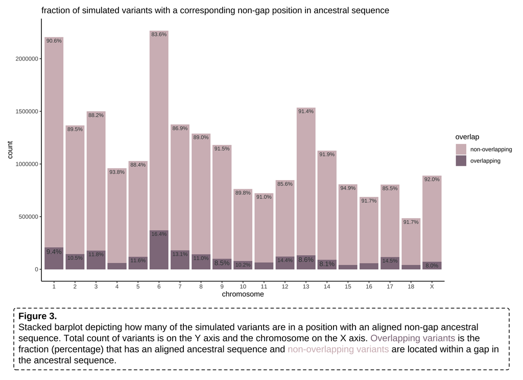

##### Table with corresponding data:

**Table 2**. Fraction of simulated SNPs that is overlapping with a reconstructed ancestral sequence. Column explanation from left to right: **i)** chromosome number **ii)** the total number of simulated variants **iii)** the total number of simulated SNPs (i.e. excluding indels) **iv)** the fraction of simulated SNPs **v)** the fraction of simulated SNPs that are overlapping with a non-gap align recontructed ancestral sequence.

|  | Number of simulated variants | No of sim. SNPs | Fraction of simulated SNPs | Fraction of sim. SNPs overlapping ancestral seq. |
| --- | --- | --- | --- | --- |
| 1 | 2 359 291 | 2 206 017 | 0.94 | 0.09 |
| 2 | 1 454 245 | 1 366 041 | 0.94 | 0.11 |
| 3 | 1 598 275 | 1 499 270 | 0.94 | 0.12 |
| 4 | 1 010 256 | 959 110 | 0.95 | 0.06 |
| 5 | 1 100 236 | 1 028 270 | 0.93 | 0.12 |
| 6 | 2 435 295 | 2 267 159 | 0.93 | 0.16 |
| 7 | 1 473 895 | 1 374 854 | 0.93 | 0.13 |
| 8 | 1 384 272 | 1 289 084 | 0.93 | 0.11 |
| 9 | 1 258 998 | 1 181 626 | 0.94 | 0.08 |
| 10 | 812 028 | 762 104 | 0.94 | 0.10 |
| 11 | 769 978 | 722 926 | 0.94 | 0.09 |
| 12 | 900 937 | 846 370 | 0.94 | 0.14 |
| 13 | 1 640 985 | 1 536 150 | 0.94 | 0.09 |
| 14 | 1 195 231 | 1 127 356 | 0.94 | 0.08 |
| 15 | 850 365 | 807 409 | 0.95 | 0.05 |
| 16 | 731 541 | 686 431 | 0.94 | 0.08 |
| 17 | 861 240 | 804 430 | 0.93 | 0.15 |
| 18 | 512 487 | 484 166 | 0.94 | 0.08 |
| X | 948 346 | 890 156 | 0.94 | 0.08 |

### Types of simulated mutations

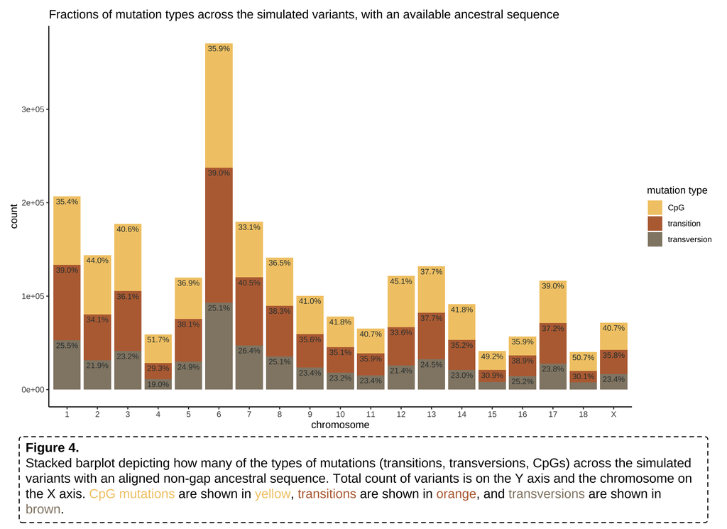

##### Table with corresponding data:

**Table 3** Fraction of mutation types across the simulated variants with an available corresponding ancestral sequence. Column explanation, starting from left: **i)** chromosome number **ii)** the total number of SNPs **iii)** the fraction of transitions **iv)** the fraction of transversions **v)** the fraction of CpG site mutations **vi)** the fraction of non-CpG mutations (transitions + transversions)

|  | No. of SNPs | Fraction transitions | Fraction transversions | Fraction CpGs | Fraction non-CpGs (1-CpGs) |
| --- | --- | --- | --- | --- | --- |
| 1 | 206 949 | 0.39 | 0.26 | 0.35 | 0.65 |
| 2 | 144 005 | 0.34 | 0.22 | 0.44 | 0.56 |
| 3 | 177 439 | 0.36 | 0.23 | 0.41 | 0.59 |
| 4 | 59 154 | 0.29 | 0.19 | 0.52 | 0.48 |
| 5 | 119 776 | 0.38 | 0.25 | 0.37 | 0.63 |
| 6 | 370 733 | 0.39 | 0.25 | 0.36 | 0.64 |
| 7 | 179 584 | 0.41 | 0.26 | 0.33 | 0.67 |
| 8 | 141 391 | 0.38 | 0.25 | 0.37 | 0.63 |
| 9 | 100 420 | 0.36 | 0.23 | 0.41 | 0.59 |
| 10 | 78 085 | 0.35 | 0.23 | 0.42 | 0.58 |
| 11 | 65 203 | 0.36 | 0.23 | 0.41 | 0.59 |
| 12 | 121 604 | 0.34 | 0.21 | 0.45 | 0.55 |
| 13 | 131 919 | 0.38 | 0.25 | 0.38 | 0.62 |
| 14 | 91 296 | 0.35 | 0.23 | 0.42 | 0.58 |
| 15 | 41 155 | 0.31 | 0.20 | 0.49 | 0.51 |
| 16 | 56 957 | 0.39 | 0.25 | 0.36 | 0.64 |
| 17 | 116 703 | 0.37 | 0.24 | 0.39 | 0.61 |
| 18 | 40 065 | 0.30 | 0.19 | 0.51 | 0.49 |
| X | 71 643 | 0.36 | 0.23 | 0.41 | 0.59 |

### Visualisation of gene density

#### and CDS overlap

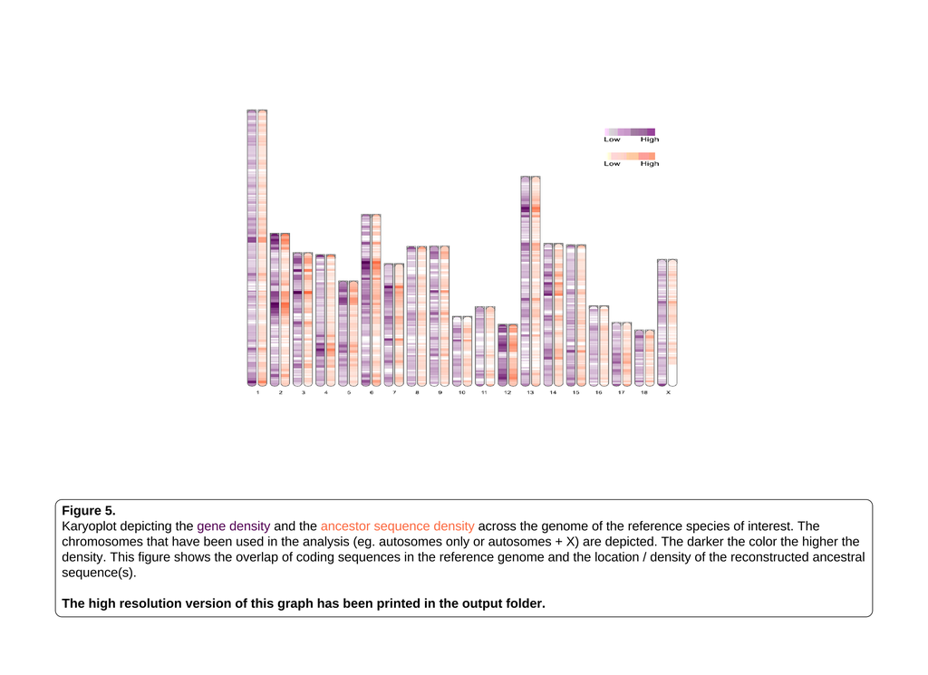

[figure not shown]

### Validation of simulation parameters

Number of mutations, fractions, and substitution rates. To make sure the simulation was performed as expected, the leftmost part is the calculated numbers and rates in the parameter files, including the total number of simulated variants per chromosome, based on information from the ancestor and reference species. The middle part is the (re)calculated numbers and rates based on the total number of simulated variants. The rightmost part is the (re)calculated numbers and rates within the subset with a corresponding non-gap ancestral sequence. The comparison of parameters and simulated variants is to make sure that the simulation has been perform as intended, and the comparison between total set and the subset is to make sure that the distribution is the same even if the variants are forced to be down-sampled due to the lack of an available ancestral sequence.

Comparison of numebr of mutations between log files and actual simulated files

[output not shown]

[output cut: 369 more lines]